# Noise Lab Sources Report

Jenna Moscaritolo

12/10/2020

## 1.0 Introduction

This project is a continuation of the Noise Lab Project from a group in the Boston University GRS MA 675 class in the Fall 2020 semester. This Noise Lab Project was about our client, Erica Walker, wanting to learn more about how to improve her app. Her app is available to volunteers and tracks noise sounds while the users answer some questions about the sources of noise, how it makes them feel, and more. In addition to her app, we utilized data from the [Analyze Boston](https://data.boston.gov/dataset/climate-ready-boston-social-vulnerability) website for social vulnerability in Boston.

In the project previous to this one, my group and I cleaned a bunch of data from Erica as there were a lot of test users. In addition, we looked at the average noise scores and joined the data with the Boston social vulnerability data to produce interactive maps using tmap(). Now, this project will be going one step further by looking at the sources of the noise and to map each ones at different decibel (dB) levels.

## 2.0 Data Cleaning

In this section, I will talk about the cleaning of the data and what research I have done.

### 2.1 Step One: Cleaning

The first step I took was cleaning the data more from before. I looked at the “Sources” column and separated the words to only contain the first word that was present in each cell.

### 2.2 Step Two: Research

The next step was to research different decibel numbers for different noise sources, assign a decibel number to each source, and group them by the same decibel level. The sources that I used to learn and decide on decibel levels with are below in the “Bibliography” section. Here is a list of the sources and their assigned decibel levels:

- fireworks - 140
- airplane - 120
- horn - 110
- alarm - 110
- construction - 110
- party - 110
- trains - 100
- music - 100
- car music - 100
- leaf blower - 90
- dog - 80
- delivery - 80
- pickup - 80
- trash - 80
- traffic - 70
- hvac - 60
- restaurant - 60
- neighbor - 60
- voices - 60
- footsteps - 50
- quiet - 20

```r
boston_data <- st_read("c7230a7a-4081-4743-b911-e18f66e1beca2020330-1-17gw6be.a4ds.shp")
measurements <- read.csv("Measurements_date.csv")
data <- read.csv("data.csv")

# Turn the data frame into sf data
epsg_wgs84 <- 4326
measurements %<>% st_as_sf(coords = c("Longitude", "Latitude")) %>% st_set_crs(epsg_wgs84)


# Make sure that measurements data has the same crs with boston_data
epsg_wgs84 <- 3857
measurements %<>% st_as_sf(coords = c("Longitude", "Latitude")) %>% st_transform(epsg_wgs84)

# Find the points of noise measurements that are in the Boston area
measurements$join <- lengths(st_intersects(measurements, boston_data))
measurements <- subset(measurements, measurements$join == 1)
joindata <- boston_data %>% st_join(measurements)


# Separating the first word in the "Genre" column - we will only use the first word
df_first_word <- separate(measurements, c("Sources"), "Sources")


df <- df_first_word[!df_first_word$Sources == "other", ]


u <- unique(df$Sources)
l <- length(u)

# All
df$fac <- factor(df$Sources, ordered = TRUE, levels = c("quiet", "footsteps", "voices", "neighbor", "restaurant", "hvac", "traffic", "trash", "pickup", "delivery", "dog", "leaf", "car", "music", "trains", "party", "construction", "alarm", "horn", "airplane", "fireworks"))

# 20 dB
df1 <- df[df$Sources == "quiet", ]
df1$fac <- factor(df1$Sources, ordered = TRUE, levels = "quiet")

# 50 dB
df2 <- df[df$Sources == "footsteps", ]
df2$fac <- factor(df2$Sources, ordered = TRUE, levels = "footsteps")

# 60 dB
df3 <- df[df$Sources == c("voices", "neighbor", "restaurant", "hvac"), ]
df3$fac <- factor(df3$Sources, ordered = TRUE, levels = c("voices", "neighbor", "restaurant", "hvac"))

# 70 dB
df4 <- df[df$Sources == "traffic", ]
df4$fac <- factor(df4$Sources, ordered = TRUE, levels = "traffic")

# 80 dB
df5 <- df[df$Sources == c("trash", "pickup", "delivery", "dog"), ]
df5$fac <- factor(df5$Sources, ordered = TRUE, levels = c("trash", "pickup", "delivery", "dog"))

# 90 dB
df6 <- df[df$Sources == "leaf", ]
df6$fac <- factor(df6$Sources, ordered = TRUE, levels = "leaf")

# 100 dB
df7 <- df[df$Sources == c("car", "music", "trains"), ]
df7$fac <- factor(df7$Sources, ordered = TRUE, levels = c("car", "music", "trains"))

# 110 dB
df8 <- df[df$Sources == c("party", "construction", "alarm", "horn"), ]
df8$fac <- factor(df8$Sources, ordered = TRUE, levels = c("party", "construction", "alarm", "horn"))

# 120 dB
df9 <- df[df$Sources == "airplane", ]
df9$fac <- factor(df9$Sources, ordered = TRUE, levels = "airplane")

# 140 dB
df10 <- df[df$Sources == "fireworks", ]
df10$fac <- factor(df10$Sources, ordered = TRUE, levels = "fireworks")
```

Map with all of the sources.

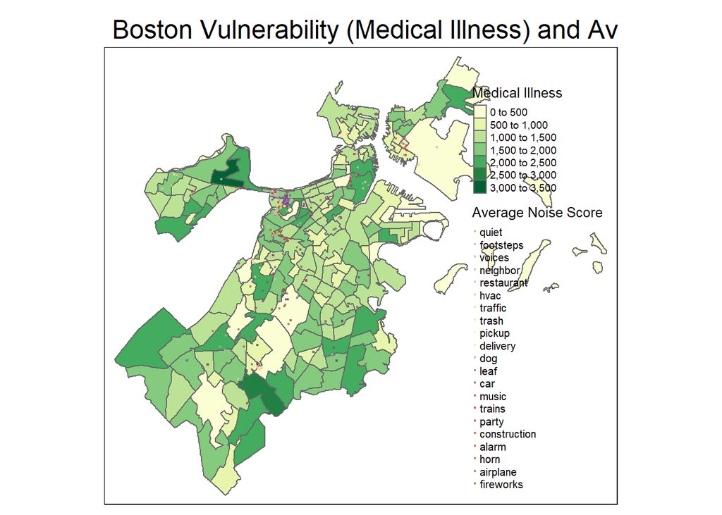

```r
map_fac <- tm_shape(boston_data) +
  tm_polygons('MedIllnes', palette = "YlGn", title = "Medical Illness") +
  tm_shape(df) +
  tm_dots(col = 'fac', size = 0.02, alpha = 0.5, palette = "Accent", title = 'Average Noise Score') +
  tm_layout(main.title = 'Boston Vulnerability (Medical Illness) and Average Noise Score (All)')
map_fac
```

Map with just “quiet”.

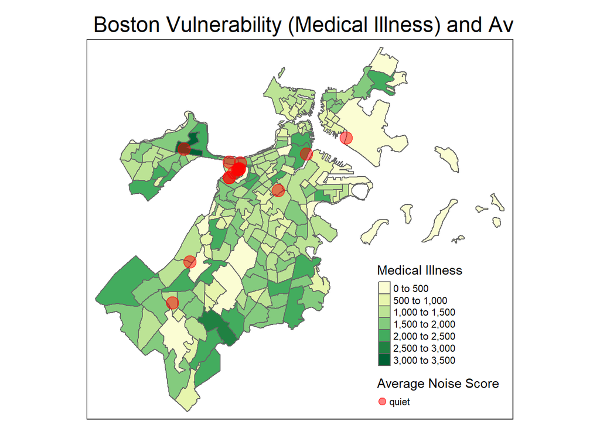

```r
map1 <- tm_shape(boston_data) +
  tm_polygons('MedIllnes', palette = "YlGn", title = "Medical Illness") +
  tm_shape(df1) +
  tm_dots(col = 'fac', size = 1, alpha = 0.5, palette = "red", title = 'Average Noise Score') +
  tm_layout(main.title = 'Boston Vulnerability (Medical Illness) and Average Noise Score (20 dB)')
map1
```

Map with just “footsteps”.

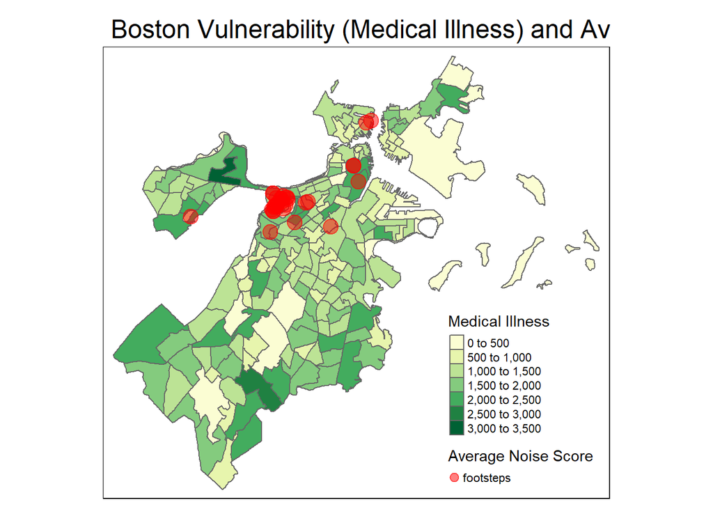

```r
map2 <- tm_shape(boston_data) +
  tm_polygons('MedIllnes', palette = "YlGn", title = "Medical Illness") +
  tm_shape(df2) +
  tm_dots(col = 'fac', size = 1, alpha = 0.5, palette = "red", title = 'Average Noise Score') +
  tm_layout(main.title = 'Boston Vulnerability (Medical Illness) and Average Noise Score (50 dB)')
map2
```

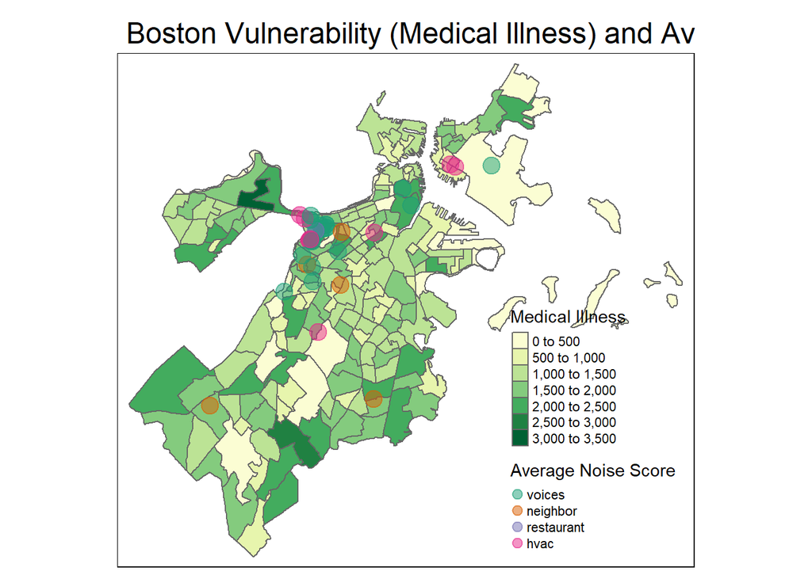

```r
map3 <- tm_shape(boston_data) +
  tm_polygons('MedIllnes', palette = "YlGn", title = "Medical Illness") +
  tm_shape(df3) +
  tm_dots(col = 'fac', size = 1, alpha = 0.5, palette = "Dark2", title = 'Average Noise Score') +
  tm_layout(main.title = 'Boston Vulnerability (Medical Illness) and Average Noise Score (60 dB)')
map3
```

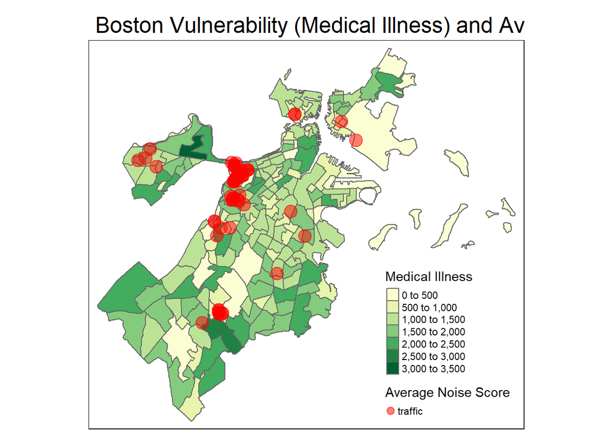

```r
map4 <- tm_shape(boston_data) +
  tm_polygons('MedIllnes', palette = "YlGn", title = "Medical Illness") +
  tm_shape(df4) +
  tm_dots(col = 'fac', size = 1, alpha = 0.5, palette = "red", title = 'Average Noise Score') +
  tm_layout(main.title = 'Boston Vulnerability (Medical Illness) and Average Noise Score (70 dB)')
map4
```

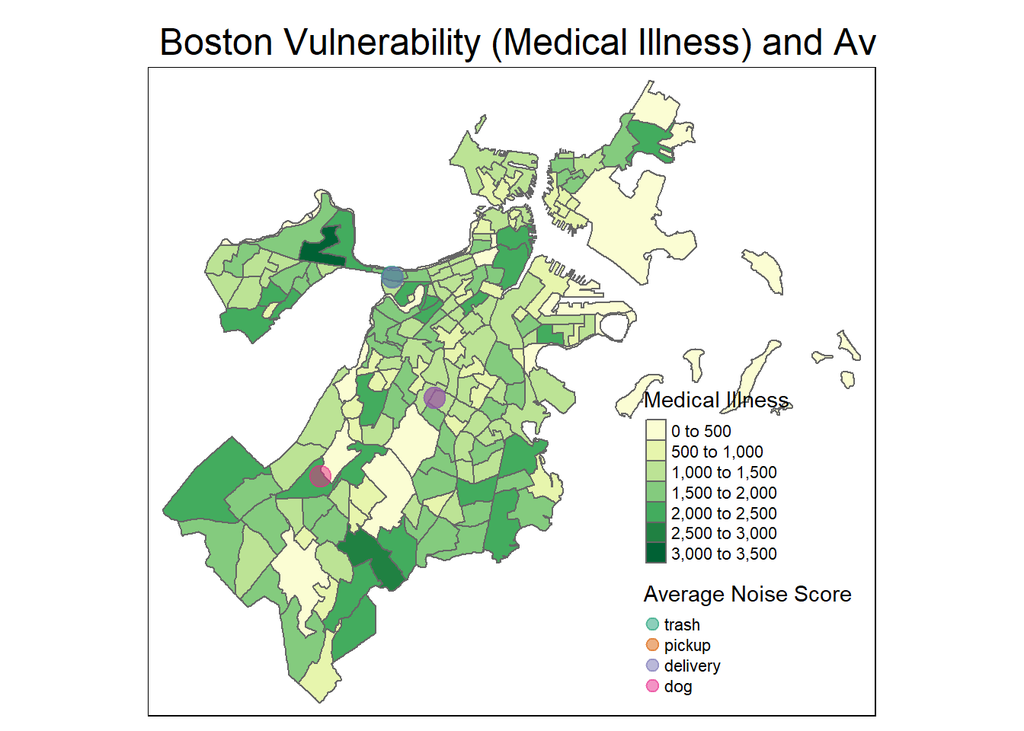

```r
map5 <- tm_shape(boston_data) +
  tm_polygons('MedIllnes', palette = "YlGn", title = "Medical Illness") +
  tm_shape(df5) +
  tm_dots(col = 'fac', size = 1, alpha = 0.5, palette = "Dark2", title = 'Average Noise Score') +
  tm_layout(main.title = 'Boston Vulnerability (Medical Illness) and Average Noise Score (80 dB)')
map5
```

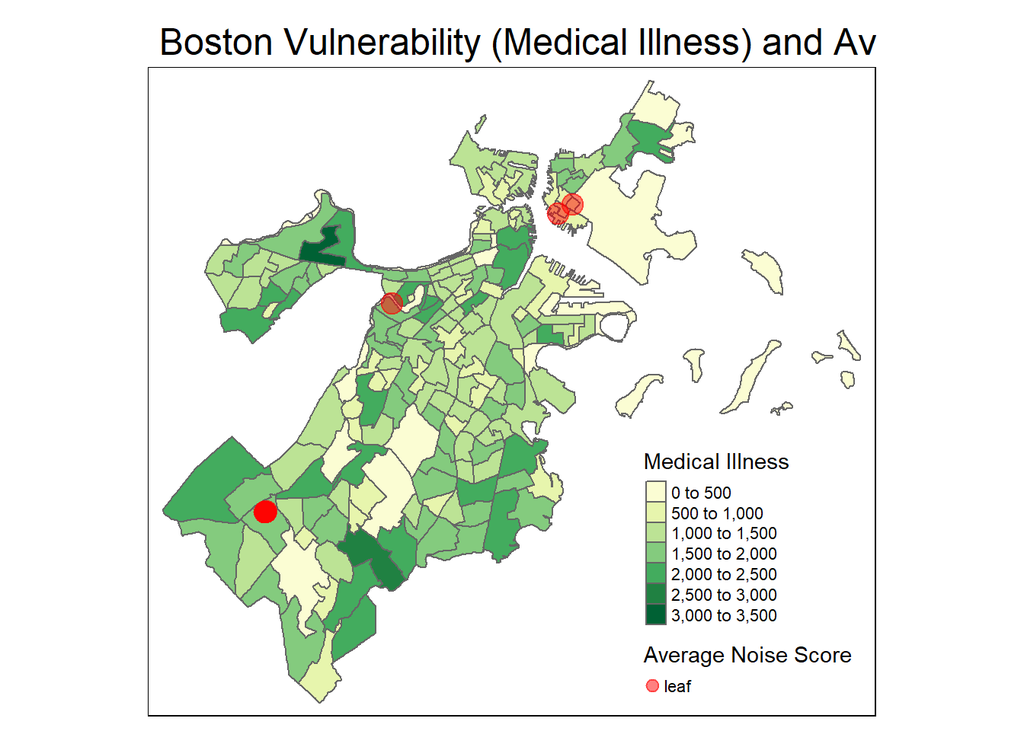

```r
map6 <- tm_shape(boston_data) +
  tm_polygons('MedIllnes', palette = "YlGn", title = "Medical Illness") +
  tm_shape(df6) +
  tm_dots(col = 'fac', size = 1, alpha = 0.5, palette = "red", title = 'Average Noise Score') +
  tm_layout(main.title = 'Boston Vulnerability (Medical Illness) and Average Noise Score (90 dB)')
map6
```

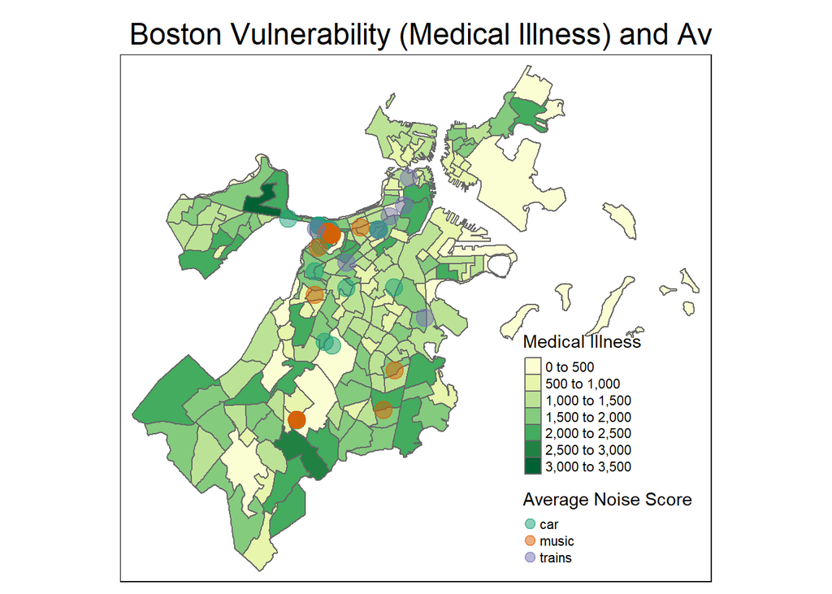

```r
map7 <- tm_shape(boston_data) +
  tm_polygons('MedIllnes', palette = "YlGn", title = "Medical Illness") +
  tm_shape(df7) +
  tm_dots(col = 'fac', size = 1, alpha = 0.5, palette = "Dark2", title = 'Average Noise Score') +
  tm_layout(main.title = 'Boston Vulnerability (Medical Illness) and Average Noise Score (100 dB)')
map7
```

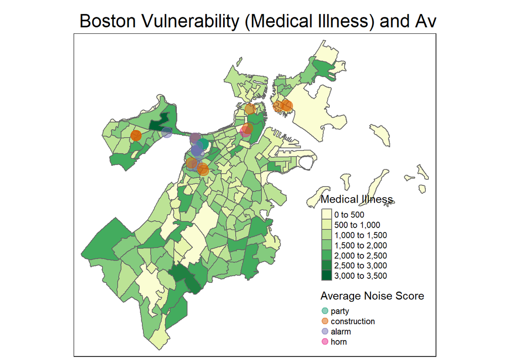

```r
map8 <- tm_shape(boston_data) +
  tm_polygons('MedIllnes', palette = "YlGn", title = "Medical Illness") +
  tm_shape(df8) +
  tm_dots(col = 'fac', size = 1, alpha = 0.5, palette = "Dark2", title = 'Average Noise Score') +
  tm_layout(main.title = 'Boston Vulnerability (Medical Illness) and Average Noise Score (110 dB)')
map8
```

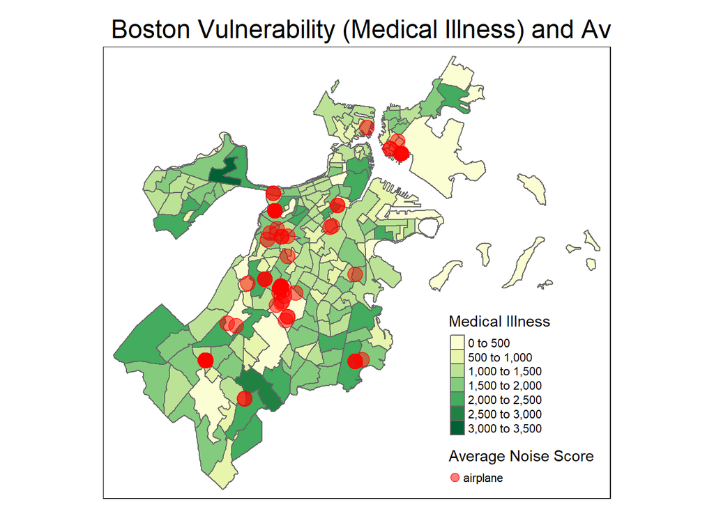

```r
map9 <- tm_shape(boston_data) +
  tm_polygons('MedIllnes', palette = "YlGn", title = "Medical Illness") +
  tm_shape(df9) +
  tm_dots(col = 'fac', size = 1, alpha = 0.5, palette = "red", title = 'Average Noise Score') +
  tm_layout(main.title = 'Boston Vulnerability (Medical Illness) and Average Noise Score (120 dB)')
map9
```

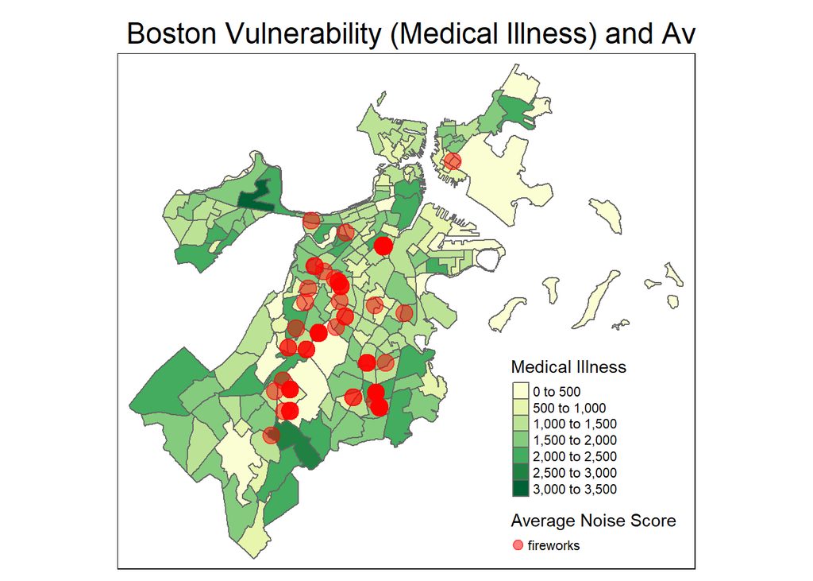

```r
map10 <- tm_shape(boston_data) +
  tm_polygons('MedIllnes', palette = "YlGn", title = "Medical Illness") +
  tm_shape(df10) +
  tm_dots(col = 'fac', size = 1, alpha = 0.5, palette = "red", title = 'Average Noise Score') +
  tm_layout(main.title = 'Boston Vulnerability (Medical Illness) and Average Noise Score (140 dB)')
map10
```

Research

Noise levels are measured in decibels. At first, people think that noise is measured by distance but it is, in fact, measured on a logarithmic scale to be able to correspond to the way our ears interpret sound pressures.

# Bibliography

https://www.faa.gov/regulations_policies/policy_guidance/noise/basics/

https://www.chem.purdue.edu/chemsafety/Training/PPETrain/dblevels.htm

https://audiology-web.s3.amazonaws.com/migrated/NoiseChart_Poster-%208.5x11.pdf_5399b289427535.32730330.pdf